# DATS 6103 - Individual Project 1 - Sabina Azim:

# Analyzing the Military Expenditure of 10 Different Nations

In this project, the military spending between the years 2014 - 2018 of the following countries will be examined:

- United States
- China
- Russia
- Germany
- United Kingdom
- France
- Italy
- Saudi Arabia
- South Korea
- Australia

## Data Source:

I used the The World Bank Database for data on the countries' military spending, GDP, and population. A lot of the World Bank data actually comes from the Stockholm International Peace Research Institute (SIPRI), which would have been another good source to use. However, I found it easier to use the World Bank since the datasets were already pretty clean and it was easy to navigate around the database to find what I needed.

- Military Expenditure: https://data-worldbank-org/indicator/MS.MIL.XPND.CD
- GDP: https://data-worldbank-org/indicator/NY.GDP.MKTP.CD
- Population: https://data.worldbank.org/indicator/SP.POP.TOTL

## Importing and Cleaning the Data:

```python
import pandas as pd
import numpy as np
import matplotlib.pyplot as plt
from IPython.display import display
import warnings
warnings.filterwarnings('ignore')

#Reading in the Total Military Expenditure, GDP, and Population data sets using read_csv since they are csv files.
mil_spend = pd.read_csv('total_mil.csv', index_col = 0, skiprows=4)
gdp = pd.read_csv('gdp.csv', index_col = 0, skiprows=4)
pop = pd.read_csv('pop.csv', index_col = 0, skiprows = 4)

#Removes scientific notation
pd.set_option('display.float_format', lambda x: '%.2f' % x)
```

```python
#Joining the 3 data sets together using append so that it is easier to see all of the data at once
df = mil_spend
df = df.append(gdp)
df = df.append(pop)

df.head()
```

| Country Name | Country Code | Indicator Name | Indicator Code | 1960 | 1961 | 1962 | 1963 | 1964 | 1965 | 1966 | ... | 2011 | 2012 | 2013 | 2014 | 2015 | 2016 | 2017 | 2018 | 2019 | Unnamed: 64 |
| --- | --- | --- | --- | --- | --- | --- | --- | --- | --- | --- | --- | --- | --- | --- | --- | --- | --- | --- | --- | --- | --- |
| Aruba | ABW | Military expenditure (current USD) | MS.MIL.XPND.CD | nan | nan | nan | nan | nan | nan | nan | ... | nan | nan | nan | nan | nan | nan | nan | nan | nan | nan |
| Afghanistan | AFG | Military expenditure (current USD) | MS.MIL.XPND.CD | nan | nan | nan | nan | nan | nan | nan | ... | 325807003.66 | 238583385.37 | 217194107.11 | 268227074.24 | 199518614.83 | 185878310.06 | 191407113.24 | 198086263.32 | nan | nan |
| Angola | AGO | Military expenditure (current USD) | MS.MIL.XPND.CD | nan | nan | nan | nan | nan | nan | nan | ... | 3639496373.54 | 4144634851.47 | 6090751702.01 | 6841864484.32 | 3608299114.62 | 2764054937.16 | 3062872913.98 | 1983613748.00 | nan | nan |
| Albania | ALB | Military expenditure (current USD) | MS.MIL.XPND.CD | nan | nan | nan | nan | nan | nan | nan | ... | 197006789.24 | 183204695.66 | 180015508.82 | 178120368.03 | 132350667.59 | 130853162.62 | 144382688.72 | 180488725.12 | nan | nan |
| Andorra | AND | Military expenditure (current USD) | MS.MIL.XPND.CD | nan | nan | nan | nan | nan | nan | nan | ... | nan | nan | nan | nan | nan | nan | nan | nan | nan | nan |

5 rows × 64 columns

```python
#Creating a columns and countries list to use to filter out the dataframe I created above to see only the years
#and countries I want to look at for this project, as well as the indicator name column so I don't confuse the
#values. Once the lists are created I created a new dataframe 'data_clean' by using loc.

columns = ['Indicator Name','2014','2015','2016','2017','2018']
countries = ['United States', 'China','Russian Federation','Germany', 'United Kingdom', 'France', 'Italy', 'Saudi Arabia','Korea, Rep.','Australia']

df_clean = df[columns]
df_clean = df_clean.loc[countries]
df_clean.head()
```

| Country Name | Indicator Name | 2014 | 2015 | 2016 | 2017 | 2018 |
| --- | --- | --- | --- | --- | --- | --- |
| United States | Military expenditure (current USD) | 609914000000.00 | 596104639000.00 | 600106443000.00 | 605802927000.00 | 648798273000.00 |
| United States | GDP (current US$) | 17521746534000.00 | 18219297584000.00 | 18707188235000.00 | 19485393853000.00 | 20529049174601.50 |
| United States | Population, total | 318301008.00 | 320635163.00 | 322941311.00 | 324985539.00 | 326687501.00 |
| China | Military expenditure (current USD) | 200772203839.98 | 214093069946.25 | 216031280078.82 | 227829417915.78 | 249996900635.14 |
| China | GDP (current US$) | 10475682846632.20 | 11061552790044.20 | 11233277146512.20 | 12310408652423.50 | 13894817110036.30 |

```python
#Creating a pivot table using the df_clean dataframe and the 'Indicator Name' and 'Country Name' as indexes
df_clean = pd.pivot_table(df_clean,index=['Indicator Name','Country Name'])

#Using transpose to makes rows into columns and columns into rows - making each country name a column
#and a year column, rather than each year being a seperate column a
mil_df = df_clean.loc['Military expenditure (current USD)'].T.reset_index()
#renaming the index column as year
mil_df.rename(columns={'index':'Year'}, inplace=True)
#using melt to change the dataframe from wide to long format - creates 3 columns for year, country, and value
mil_df_new = pd.melt(mil_df, id_vars=['Year'],var_name=['Country Name'])
#renaming value column so we know what this value is displaying
mil_df_new.rename(columns={'value':'Military Expenditure'}, inplace=True)


#I go on to the same exact thing to the gdp data and population data as well to get everything ready to be merged.
gdp_df = df_clean.loc['GDP (current US$)'].T.reset_index()
gdp_df.rename(columns={'index':'Year'}, inplace=True)
gdp_df_new = pd.melt(gdp_df, id_vars=['Year'],var_name=['Country Name'])
gdp_df_new.rename(columns={'value':'GDP'}, inplace=True)

pop_df = df_clean.loc['Population, total'].T.reset_index()
pop_df.rename(columns={'index':'Year'}, inplace=True)
pop_df_new = pd.melt(pop_df, id_vars=['Year'],var_name=['Country Name'])
pop_df_new.rename(columns={'value':'Population'}, inplace=True)

#Merging the three reshaped data frames together and setting the Country Name and Years as the indexes, as well as
#sorting the indexes.
data_merge = pd.merge(pd.merge(mil_df_new, gdp_df_new), pop_df_new)
data_merge = data_merge.set_index(['Country Name','Year']).sort_index()
```

```python
#Adding on 3 columns to my data_merge dataframe that I think will be useful for my analysis later on
data_merge['Per Capita Military Spending'] = data_merge['Military Expenditure']/data_merge['Population']
data_merge['Per Capita GDP'] = data_merge['GDP']/data_merge['Population']
data_merge['Military Expenditure (% of GDP)'] = 100*data_merge['Military Expenditure']/data_merge['GDP']
```

```python
#A glimpse at the final dataframe I will be using to pull information out of to conduct my analysis
data_merge.head(10)
```

| Country Name | Year | Military Expenditure | GDP | Population | Per Capita Military Spending | Per Capita GDP | Military Expenditure (% of GDP) |
| --- | --- | --- | --- | --- | --- | --- | --- |
| Australia | 2014 | 25783708714.00 | 1467483705131.74 | 23475686.00 | 1098.32 | 62510.79 | 1.76 |
|  | 2015 | 24045569111.02 | 1351693984524.50 | 23815995.00 | 1009.64 | 56755.72 | 1.78 |
|  | 2016 | 26382947050.02 | 1208846993739.99 | 24190907.00 | 1090.61 | 49971.13 | 2.18 |
|  | 2017 | 27691112416.85 | 1330135756844.41 | 24601860.00 | 1125.57 | 54066.47 | 2.08 |
|  | 2018 | 26711834224.74 | 1433904348500.12 | 24982688.00 | 1069.21 | 57395.92 | 1.86 |
| China | 2014 | 200772203839.98 | 10475682846632.20 | 1364270000.00 | 147.16 | 7678.60 | 1.92 |
|  | 2015 | 214093069946.25 | 11061552790044.20 | 1371220000.00 | 156.13 | 8066.94 | 1.94 |
|  | 2016 | 216031280078.82 | 11233277146512.20 | 1378665000.00 | 156.70 | 8147.94 | 1.92 |
|  | 2017 | 227829417915.78 | 12310408652423.50 | 1386395000.00 | 164.33 | 8879.44 | 1.85 |
|  | 2018 | 249996900635.14 | 13894817110036.30 | 1392730000.00 | 179.50 | 9976.68 | 1.80 |

## Comparing the Overall Military Spending of all 10 Countries:

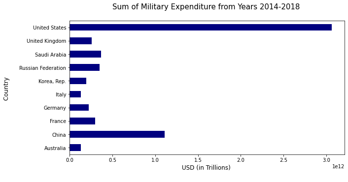

```python
#Sum of the total Military Expenditure per country from the years 2014-2018
#Using loc to select the Military Expenditure column and group by so that when I call the sum function it will
#sum the values by Country
tm = data_merge.loc[:,'Military Expenditure'].groupby('Country Name').sum()

#Creating a simple bar graph to show the data above.

plt.figure(figsize=(10, 5)) #how big I want the graph to be
tm.plot(kind='barh', color="navy") #type of graph, color of graph
plt.xlabel('USD (in Trillions) \n', fontsize=12) #Label and fontsize for the x-axis
plt.ylabel('Country \n', fontsize=12) #Label and fontsize for the y-axis
plt.title('Sum of Military Expenditure from Years 2014-2018 \n',fontsize=15) #Title and fontsize
plt.show()
```

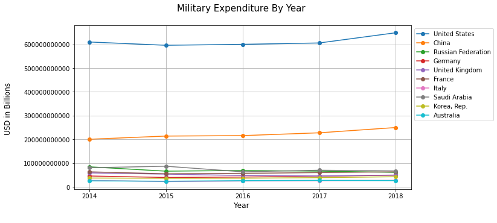

```python
plt.figure(figsize=(10, 5))

#This next graph will display Military Expenditure for each country by year.
#Using a for loop to loop through and plot the countries in the list I created above. I used loc to select just
#the Military Expenditure column

for country in countries:

    plt.plot(data_merge.loc[country,'Military Expenditure'], marker='o')

plt.legend(countries, bbox_to_anchor=(1, 1)) #specifies where I want the legend to be and how big
plt.title("Military Expenditure By Year \n", fontsize=15)
plt.gcf().axes[0].yaxis.get_major_formatter().set_scientific(False) #gets rid of scientific notation on y-axis
plt.xlabel("Year \n", fontsize=12)
plt.ylabel("USD in Billions \n", fontsize=12)
plt.grid() #I decided to add the grid so its easier to differentiate between the values
```

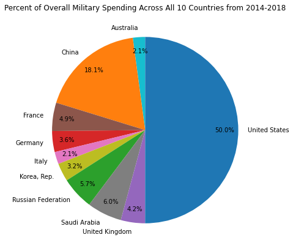

```python
#Adding together all of the values (found previously, refer to tm) for the military expenditure sum over the
#years for each country. This will give me the total amount of military spending that occured between 2014-2018
#by all 10 of these countries. Using this we can see what percentage each country makes up when it comes to
#their military expenditure within the selected time period.

total = tm.sum()

total_percent = tm/total

#I decided this would make the most sense as a pie chart so that is what I'm creating here. I was having trouble
#with the colors matching the previous graphs so I made lists to specify the labels and colors just to be sure
#it is all cohesive.

labels = ['Australia', 'China','France','Germany', 'Italy', 'Korea, Rep.', 'Russian Federation', 'Saudi Arabia','United Kingdom','United States']
colors = ['C9','C1','C5','C3', 'C6', 'C8','C2', 'C7','C4','C0']

#The graph will be showing the total_percents I found earlier, using the labels list as labels, colors list as
#colors, autopct will control how the percents are displayed on the graph, pctdistance will make it so that
#the percents are far enough from the center that they are no overlapping, and startangle will control the
#orientation of the grpah
plt.figure(figsize=(10, 7))
plt.pie(total_percent,labels=labels, colors=colors, autopct="%.1f%%", pctdistance=0.85, startangle=90)
plt.title('Percent of Overall Military Spending Across All 10 Countries from 2014-2018', fontsize = 12)
plt.show()
```

## Comparing Each Country's Military Expenditure to their GDP:

```python
#I am starting out by creating a dataframe by using loc to pull out the Military Expenditure and GDP columns
#from the larger data_merge dataframe.

gdp_vs_mil = data_merge.loc[:,['Military Expenditure', 'GDP']]
gdp_vs_mil.head()
```

| Country Name | Year | Military Expenditure | GDP |
| --- | --- | --- | --- |
| Australia | 2014 | 25783708714.00 | 1467483705131.74 |
|  | 2015 | 24045569111.02 | 1351693984524.50 |
|  | 2016 | 26382947050.02 | 1208846993739.99 |
|  | 2017 | 27691112416.85 | 1330135756844.41 |
|  | 2018 | 26711834224.74 | 1433904348500.12 |

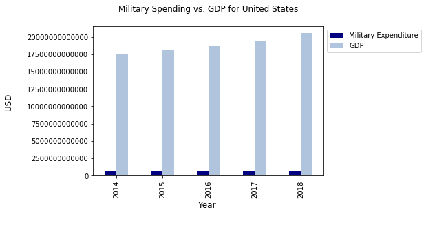

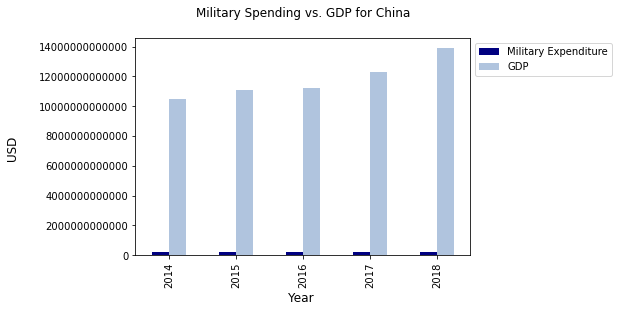

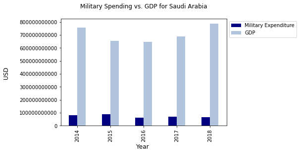

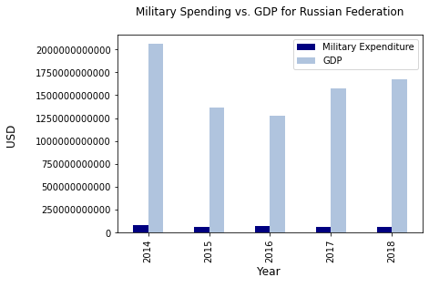

```python
#Here I'm Creating a function that will create a graph comparing each individual country's Military Expenditure to
#their GDP for each year from 2014-2018. I thought this would be a good way to understand military spending
#in each country individually before looking at the bigger picture and comparing the countries to eachother.

def plot_mil_gdp(country):
    df = gdp_vs_mil.loc[country]
    df.plot(kind="bar", color = ('navy','lightsteelblue'))
    plt.legend(bbox_to_anchor=(1, 1))
    plt.title('Military Spending vs. GDP for '  + str(country) + '\n')
    plt.gcf().axes[0].yaxis.get_major_formatter().set_scientific(False)
    plt.xlabel('Year \n', fontsize=12)
    plt.ylabel('USD \n', fontsize=12)
    plt.show()

#You can use this function to call whichever country's Military Expenditure vs. GDP plot you would like to see. I
#chose a couple of different countries which I thought would be the most interesting (countries with high mil
#spending) - taking into account the plots we've already seen above.

plot_mil_gdp('United States')
plot_mil_gdp('China')
plot_mil_gdp('Saudi Arabia')
plot_mil_gdp('Russian Federation')
```

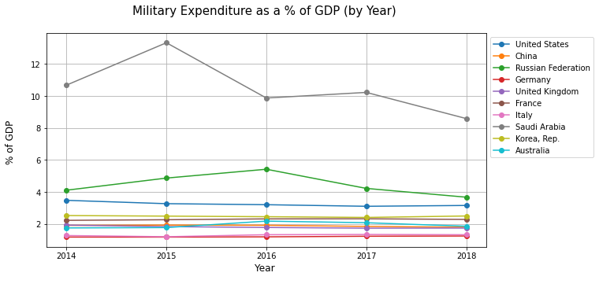

```python
#The above graphs are good to analyze the value each country places individually on their Military Spending,
#but they don't help in comparing Military Spending between the countries. This next plot will show Military
#Spending as a % of GDP - comparing all 10 countries over the 5 year period.

plt.figure(figsize=(10, 5))

#Using a for loop to loop through the countries like I did previously, I'm basically repeating the same process,
#but this time using loc to zero in on the 'Military Expenditure (% of GDP)' column which I created earlier by
#dividing each country's Military Expenditure by their GDP and multiplying by 100 (for each particular year).

for country in countries:

    plt.plot(data_merge.loc[country,'Military Expenditure (% of GDP)'], marker='o')

plt.legend(countries, bbox_to_anchor=(1, 1))
plt.title('Military Expenditure as a % of GDP (by Year) \n', fontsize=15)
plt.xlabel("Year \n", fontsize=12)
plt.ylabel("% of GDP \n", fontsize=12)
plt.grid()
```

## Comparing Per Capita Military Spending to Per Capita GDP:

```python
#Creating a new dataframe containing the Military Expenditure(Total and Per Capita) and GDP(Total and Per Capita).
#I also added 2 columns to show the absolute values and percentages for the Per Capita Military Spending as a
#share of Per Capita GDP.

per_cap = data_merge.loc[:,['Military Expenditure', 'GDP','Per Capita Military Spending','Per Capita GDP']]
per_cap['Per Cap Mil Spending/Per Cap GDP'] = per_cap['Per Capita Military Spending']/per_cap['Per Capita GDP']
per_cap['Per Cap Mil Spending as a % of Per Cap GDP'] = 100*per_cap['Per Cap Mil Spending/Per Cap GDP']
per_cap.head()
```

| Country Name | Year | Military Expenditure | GDP | Per Capita Military Spending | Per Capita GDP | Per Cap Mil Spending/Per Cap GDP | Per Cap Mil Spending as a % of Per Cap GDP |
| --- | --- | --- | --- | --- | --- | --- | --- |
| Australia | 2014 | 25783708714.00 | 1467483705131.74 | 1098.32 | 62510.79 | 0.02 | 1.76 |
|  | 2015 | 24045569111.02 | 1351693984524.50 | 1009.64 | 56755.72 | 0.02 | 1.78 |
|  | 2016 | 26382947050.02 | 1208846993739.99 | 1090.61 | 49971.13 | 0.02 | 2.18 |
|  | 2017 | 27691112416.85 | 1330135756844.41 | 1125.57 | 54066.47 | 0.02 | 2.08 |
|  | 2018 | 26711834224.74 | 1433904348500.12 | 1069.21 | 57395.92 | 0.02 | 1.86 |

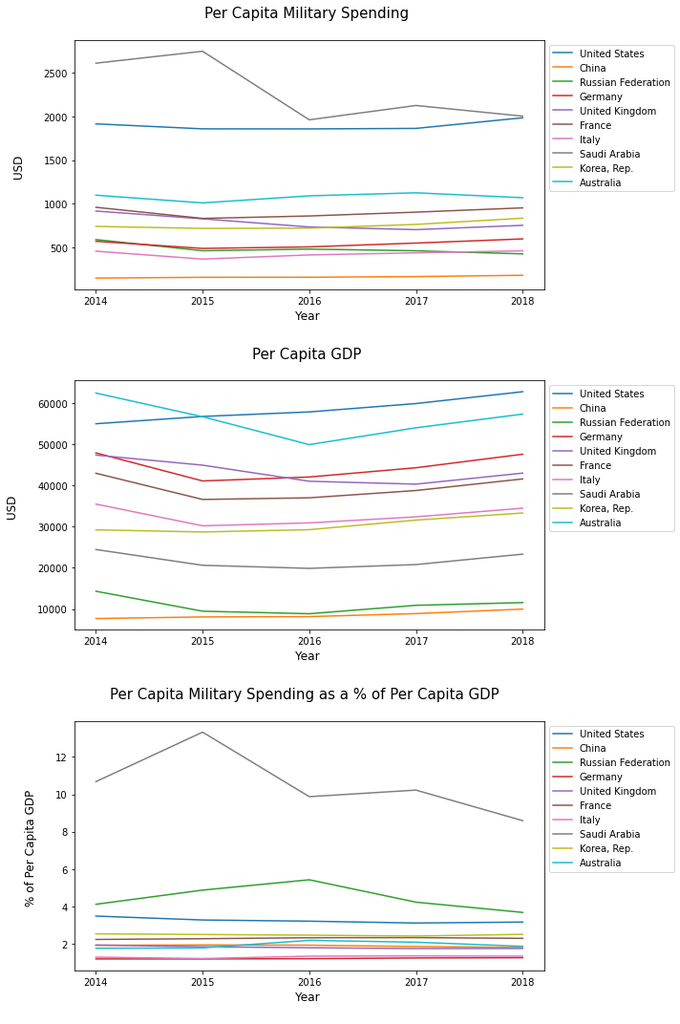

```python
plt.figure(figsize=(10,15))

for country in countries:

#creating subplots so that I don't have to run them all seperately - The first 3 # in the parenthesis
#is the number of columns I want the subplots to appear in, the second number is the number of rows, and the
#number which each graph will appear as.

    #First plot is going to be comparing Per Capita Military Spending for each country
    plt.subplot(311)
    plt.tight_layout()
    plt.plot(per_cap.loc[country,'Per Capita Military Spending'])
    plt.legend(countries, bbox_to_anchor=(1, 1))
    plt.title('Per Capita Military Spending \n', fontsize=15)
    plt.xlabel("Year \n", fontsize=12)
    plt.ylabel("USD \n", fontsize=12)
    #Second plot is going to be comparing Per Capita GDP for each country
    plt.subplot(312)
    plt.plot(per_cap.loc[country,'Per Capita GDP'])
    plt.legend(countries, bbox_to_anchor=(1, 1))
    plt.title('Per Capita GDP \n', fontsize=15)
    plt.xlabel("Year \n", fontsize=12)
    plt.ylabel("USD \n", fontsize=12)
    #Third plot is Per Capita Military Spending as a % of the Per Capita GDP for each country
    plt.subplot(313)
    plt.plot(per_cap.loc[country,'Per Cap Mil Spending as a % of Per Cap GDP'])
    plt.legend(countries, bbox_to_anchor=(1, 1))
    plt.title('Per Capita Military Spending as a % of Per Capita GDP  \n', fontsize=15)
    plt.xlabel("Year \n", fontsize=12)
    plt.ylabel("% of Per Capita GDP \n", fontsize=12)
```